# LAMMPSPatternsTest

```python
import sys, os, getpass, warnings
warnings.filterwarnings('ignore')
#sys.path.append(os.path.abspath(os.path.join(os.path.dirname(os.path.realpath("__file__")), '..', 'src')))  # append parent directory to search path
from patterns.visualizer import Visualizer
```

Bring in data from database and annotate it with *locc*, *locc+*, *locc-*, *change-size-cos* = *1-similarity* (**expensive call**). The data is cached locally after it's fetched from the database. To force re-downloading of this data from the server, specify the `cache=False` parameter.

```python
vis = Visualizer(project_name='lammps')
vis.get_data(cache=True)
```

```python
all_commits = vis.commit_data
all_commits.head()
```

| datetime | sha | branch | author | email | message | filepath | diff | year | month | day | doy | dow | locc | locc- | locc+ | change-size-cos |
| --- | --- | --- | --- | --- | --- | --- | --- | --- | --- | --- | --- | --- | --- | --- | --- | --- |
| 2021-02-22 04:05:20 | f3ee948450bbc63eef80c3bad1a2de382dda7b75 | * master\n remotes/origin/HEAD -> origin/mast... | Axel Kohlmeyer | akohlmey@gmail.com | need to use column 1 in fix ave/time example | doc/src/compute_temp_chunk.rst | - fix 1 all ave/time 100 1 100 c_myChunk fil... | 2021 | 2 | 22 | 53 | Monday | 2 | 1 | 1 | 0.022992 |
| 2021-02-21 17:40:11 | 4786391fad023faaa676de5957cd3ea7d3ead24f | * master\n remotes/origin/HEAD -> origin/mast... | Axel Kohlmeyer | akohlmey@gmail.com | must explicitly register fix gpu | cmake/Modules/Packages/GPU.cmake | +RegisterFixStyle(${GPU_SOURCES_DIR}/fix_gpu.h) | 2021 | 2 | 21 | 52 | Sunday | 0 | 0 | 0 | 0.000000 |
| 2021-02-21 14:11:38 | e0e89c588ba0c907f60824806dcf5ea84e8090d5 | * master\n remotes/origin/HEAD -> origin/mast... | Axel Kohlmeyer | akohlmey@gmail.com | correct library prefix name use also for build... | cmake/Modules/YAML.cmake | - BUILD_BYPRODUCTS <INSTAL... | 2021 | 2 | 21 | 52 | Sunday | 2 | 1 | 1 | 0.117220 |
| 2021-02-21 13:42:30 | db95552f2b4c28c630c5c9a35b3a83b7892e990e | * master\n remotes/origin/HEAD -> origin/mast... | Axel Kohlmeyer | akohlmey@gmail.com | update md5sum for updated archive (again) | cmake/Modules/OpenCLLoader.cmake | - URL_MD5 d89ab1dc1... | 2021 | 2 | 21 | 52 | Sunday | 2 | 1 | 1 | 0.208333 |
| 2021-02-21 13:21:45 | 1a68d761a3060cfd7c8ead56b495df070a847a23 | * master\n remotes/origin/HEAD -> origin/mast... | Axel Kohlmeyer | akohlmey@gmail.com | correct how to construct the path to the gener... | cmake/Modules/OpenCLLoader.cmake | - BUILD_BYPRODUCTS <BINARY_... | 2021 | 2 | 21 | 52 | Sunday | 3 | 2 | 1 | 0.287205 |

## Remove all noncode files

The determination of what is code is made by including common suffixes, as well as checking manually a sampling of ECP projects for the suffixes used for things that can be labeled as code (vs. input simulation data, documentation, or generated files).

```python
vis.remove_noncode()
print("Removed %d noncode files!" % (all_commits.shape[0] - vis.commit_data.shape[0]))
vis.commit_data.head()
```

```
Removed 71594 noncode files!
```

| datetime | sha | branch | author | email | message | filepath | diff | year | month | day | doy | dow | locc | locc- | locc+ | change-size-cos |
| --- | --- | --- | --- | --- | --- | --- | --- | --- | --- | --- | --- | --- | --- | --- | --- | --- |
| 2021-02-21 17:40:11 | 4786391fad023faaa676de5957cd3ea7d3ead24f | * master\n remotes/origin/HEAD -> origin/mast... | Axel Kohlmeyer | akohlmey@gmail.com | must explicitly register fix gpu | cmake/Modules/Packages/GPU.cmake | +RegisterFixStyle(${GPU_SOURCES_DIR}/fix_gpu.h) | 2021 | 2 | 21 | 52 | Sunday | 0 | 0 | 0 | 0.000000 |
| 2021-02-21 14:11:38 | e0e89c588ba0c907f60824806dcf5ea84e8090d5 | * master\n remotes/origin/HEAD -> origin/mast... | Axel Kohlmeyer | akohlmey@gmail.com | correct library prefix name use also for build... | cmake/Modules/YAML.cmake | - BUILD_BYPRODUCTS <INSTAL... | 2021 | 2 | 21 | 52 | Sunday | 2 | 1 | 1 | 0.117220 |
| 2021-02-21 13:42:30 | db95552f2b4c28c630c5c9a35b3a83b7892e990e | * master\n remotes/origin/HEAD -> origin/mast... | Axel Kohlmeyer | akohlmey@gmail.com | update md5sum for updated archive (again) | cmake/Modules/OpenCLLoader.cmake | - URL_MD5 d89ab1dc1... | 2021 | 2 | 21 | 52 | Sunday | 2 | 1 | 1 | 0.208333 |
| 2021-02-21 13:21:45 | 1a68d761a3060cfd7c8ead56b495df070a847a23 | * master\n remotes/origin/HEAD -> origin/mast... | Axel Kohlmeyer | akohlmey@gmail.com | correct how to construct the path to the gener... | cmake/Modules/OpenCLLoader.cmake | - BUILD_BYPRODUCTS <BINARY_... | 2021 | 2 | 21 | 52 | Sunday | 3 | 2 | 1 | 0.287205 |
| 2021-02-21 13:20:36 | 06f6766ed6dab0ac18607ea9ee9d237a09569716 | * master\n remotes/origin/HEAD -> origin/mast... | Axel Kohlmeyer | akohlmey@gmail.com | CMAKE_FIND_LIBRARY_PREFIXES is a path. must us... | cmake/Modules/GTest.cmake | - BUILD_BYPRODUCTS <BINARY_... | 2021 | 2 | 21 | 52 | Sunday | 8 | 4 | 4 | 0.104598 |

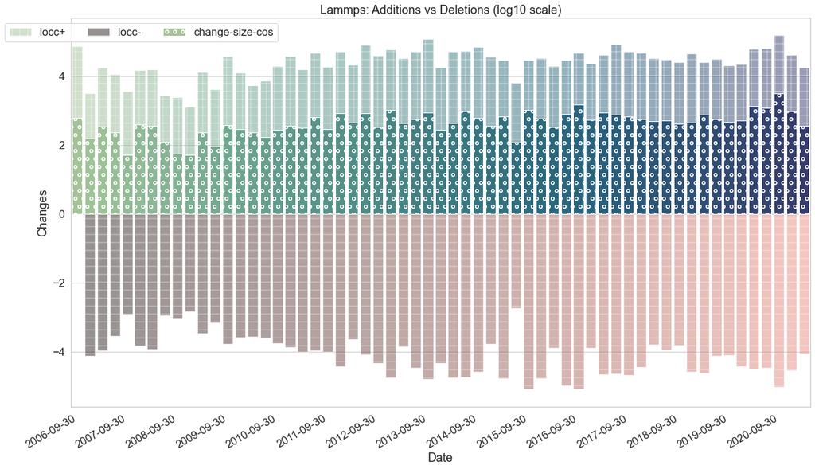

```python
df = vis.plot_overall_project_locc(time_range=None, log=True)
```

to focus on a given year and/or month, set *year* and *month* fields

```python
vis.set_year(2020)
vis.set_month(7)
```

to plot for a given year, provide *time_range='year'*

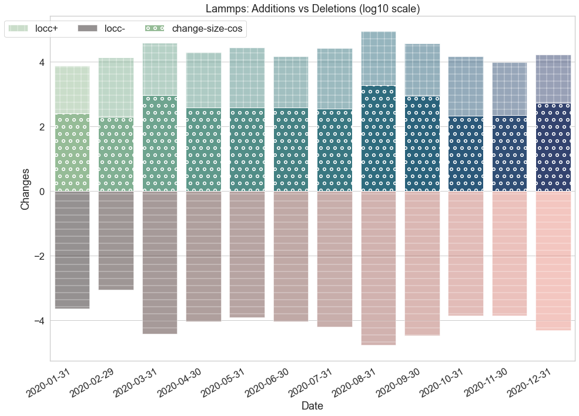

```python
df = vis.plot_overall_project_locc(time_range='year',log=True)
```

similarly to plot for a given month, set *time_range='month'*

| datetime | year | month | day | doy | locc | locc- | locc+ | change-size-cos | date |
| --- | --- | --- | --- | --- | --- | --- | --- | --- | --- |
| 2020-07-01 | 26260 | 91 | 13 | 2379 | 137 | -1.612784 | 1.982271 | 0.928952 | 2020-07-01 |
| 2020-07-02 | 98980 | 343 | 98 | 9016 | 472 | -2.350248 | 2.394452 | 1.223762 | 2020-07-02 |
| 2020-07-03 | 32320 | 112 | 48 | 2960 | 210 | -1.653213 | 2.217484 | 1.050881 | 2020-07-03 |
| 2020-07-04 | 177760 | 616 | 352 | 16368 | 2881 | -2.673942 | 3.381837 | 1.707004 | 2020-07-04 |
| 2020-07-05 | 34340 | 119 | 85 | 3179 | 510 | -2.252853 | 2.519828 | 0.805336 | 2020-07-05 |
| 2020-07-06 | 58580 | 203 | 174 | 5452 | 800 | -2.176091 | 2.812913 | 1.317511 | 2020-07-06 |
| 2020-07-07 | 197960 | 686 | 686 | 18522 | 1630 | -2.542825 | 3.107549 | 1.480651 | 2020-07-07 |
| 2020-07-08 | 157560 | 546 | 624 | 14820 | 502 | -1.949390 | 2.615950 | 1.791581 | 2020-07-08 |
| 2020-07-09 | 64640 | 224 | 288 | 6112 | 1860 | -2.564666 | 3.174060 | 1.119974 | 2020-07-09 |
| 2020-07-10 | 54540 | 189 | 270 | 5184 | 3191 | -3.019947 | 3.331225 | 1.006564 | 2020-07-10 |
| 2020-07-11 | 40400 | 140 | 220 | 3860 | 1278 | -2.808211 | 2.802774 | 0.945936 | 2020-07-11 |
| 2020-07-12 | 303000 | 1050 | 1800 | 29100 | 12126 | -3.755570 | 3.808211 | 0.822897 | 2020-07-12 |
| 2020-07-13 | 44440 | 154 | 286 | 4290 | 1354 | -1.954243 | 3.101747 | 0.743404 | 2020-07-13 |
| 2020-07-14 | 48480 | 168 | 336 | 4704 | 3101 | -2.994757 | 3.324899 | 1.015489 | 2020-07-14 |
| 2020-07-15 | 20200 | 70 | 150 | 1970 | 98 | -1.518514 | 1.812913 | 0.710336 | 2020-07-15 |
| 2020-07-16 | 141400 | 490 | 1120 | 13860 | 638 | -2.445604 | 2.555094 | 1.405518 | 2020-07-16 |
| 2020-07-17 | 36360 | 126 | 306 | 3582 | 185 | -1.982271 | 1.949390 | 0.601384 | 2020-07-17 |
| 2020-07-18 | 46460 | 161 | 414 | 4600 | 699 | -2.509203 | 2.575188 | 0.850580 | 2020-07-18 |
| 2020-07-19 | 36360 | 126 | 342 | 3618 | 398 | -2.201397 | 2.378398 | 0.726260 | 2020-07-19 |
| 2020-07-20 | 4040 | 14 | 40 | 404 | 49 | -1.278754 | 1.477121 | 0.128265 | 2020-07-20 |
| 2020-07-21 | 6060 | 21 | 63 | 609 | 0 | inf | -inf | -inf | 2020-07-21 |
| 2020-07-22 | 8080 | 28 | 88 | 816 | 114 | -1.792392 | 1.716003 | 0.108864 | 2020-07-22 |
| 2020-07-23 | 0 | 0 | 0 | 0 | 0 | inf | -inf | -inf | 2020-07-23 |
| 2020-07-24 | 12120 | 42 | 144 | 1236 | 78 | -1.544068 | 1.633468 | 0.433051 | 2020-07-24 |
| 2020-07-25 | 8080 | 28 | 100 | 828 | 315 | -2.198657 | 2.195900 | 0.053561 | 2020-07-25 |
| 2020-07-26 | 0 | 0 | 0 | 0 | 0 | inf | -inf | -inf | 2020-07-26 |
| 2020-07-27 | 76760 | 266 | 1026 | 7942 | 424 | -1.986772 | 2.514548 | 0.760847 | 2020-07-27 |
| 2020-07-28 | 4040 | 14 | 56 | 420 | 111 | -1.716003 | 1.770852 | 0.045624 | 2020-07-28 |
| 2020-07-29 | 76760 | 266 | 1102 | 8018 | 8152 | -3.578066 | 3.640183 | 1.227497 | 2020-07-29 |
| 2020-07-30 | 34340 | 119 | 510 | 3604 | 349 | -2.064458 | 2.367356 | 0.971480 | 2020-07-30 |
| 2020-07-31 | 38380 | 133 | 589 | 4047 | 509 | -2.012837 | 2.608526 | 0.865130 | 2020-07-31 |

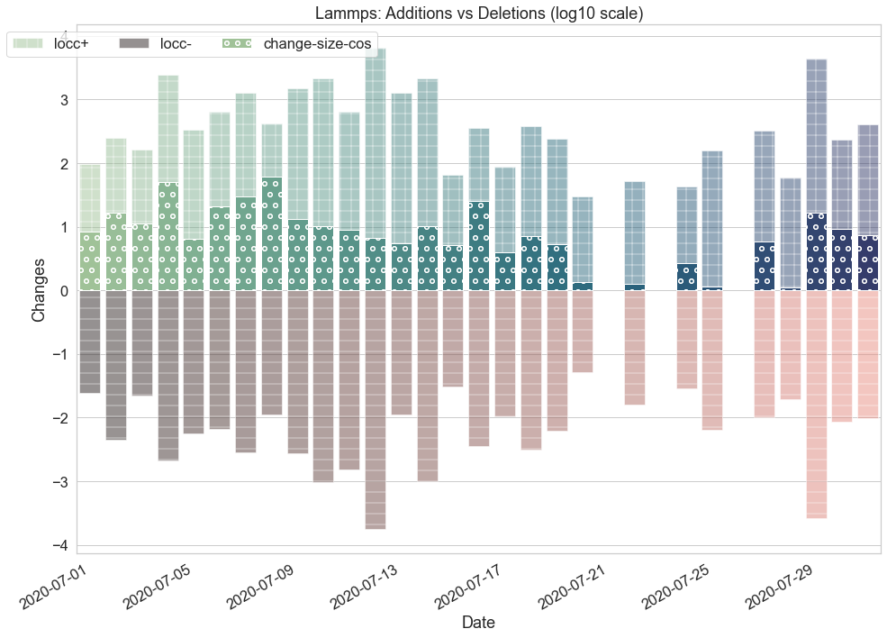

```python
vis.plot_overall_project_locc(time_range='month',log=True)
```

### Averages: Total changed lines over time

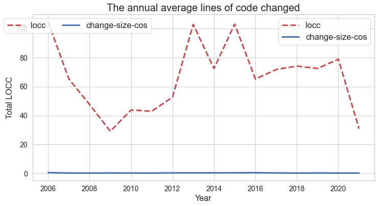

```python
vis.plot_total_locc_avg()
```

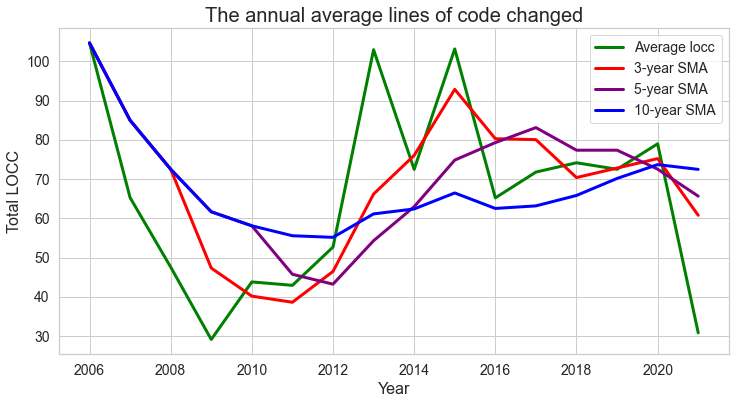

```python
vis.plot_total_locc_moving_avgs()
```

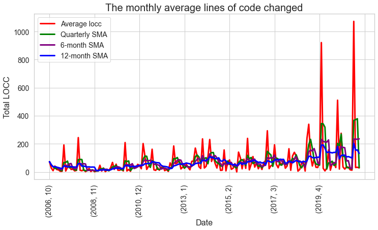

```python
vis.plot_total_locc_moving_avgs_M()
```

## Total changed lines over time

This reflects changed lines of code as reported in git commit diffs.

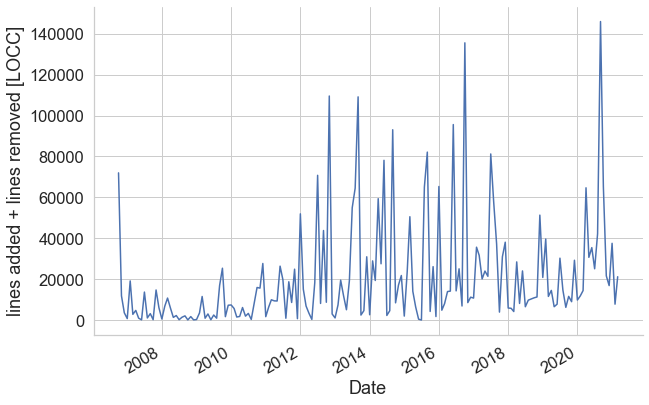

```python
df = vis.plot_project_locc_line()
```

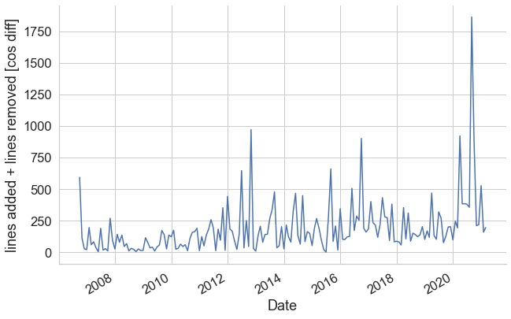

```python
df2 = vis.plot_project_locc_line(locc=False)
```

| datetime | year | month | day | doy | locc | locc- | locc+ | change-size-cos |
| --- | --- | --- | --- | --- | --- | --- | --- | --- |
| 2006-09-30 00:00:00+00:00 | 1203600 | 5400 | 16201 | 162001 | 71981 | 0 | 71981 | 593.000000 |
| 2006-10-31 00:00:00+00:00 | 254762 | 1270 | 937 | 35608 | 11815 | 11590 | 225 | 110.514378 |
| 2006-11-30 00:00:00+00:00 | 116348 | 638 | 503 | 18135 | 3509 | 1223 | 2286 | 25.697748 |
| 2006-12-31 00:00:00+00:00 | 96288 | 576 | 609 | 16641 | 695 | 176 | 519 | 19.418004 |
| 2007-01-31 00:00:00+00:00 | 1029591 | 513 | 14849 | 14849 | 19118 | 7173 | 11945 | 194.033084 |

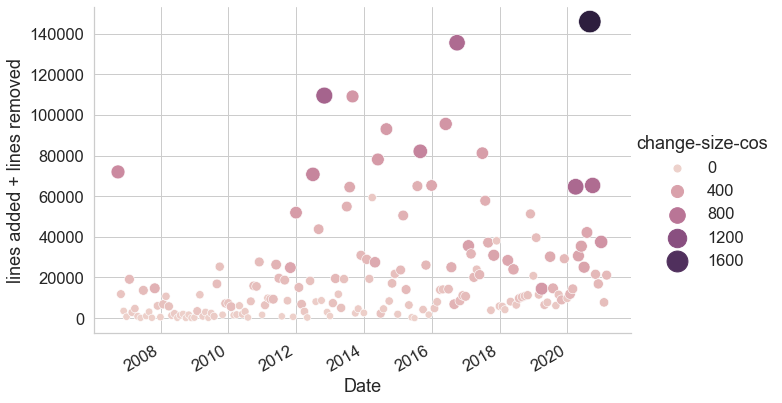

```python
import seaborn as sns
sns.set(font_scale=1.5)
with sns.axes_style("whitegrid"):
    g = sns.relplot(data=df2, x="datetime", y="locc", size="change-size-cos", hue="change-size-cos", sizes=(50, 500),
                    height=6, aspect=1.5, kind="scatter")
    g.ax.set_xlabel('Date')
    g.ax.set_ylabel('lines added + lines removed')
    g.fig.autofmt_xdate()
    g.fig.show()
df.head()
```

### Using a distance metric to adjust the size of the changes

We use the python textdistance module. The following algorithms have been integrated with the visualizer.

```
'cos', 'hamming', 'damerau_levenshtein', 'jaccard', 'jaro', 'jaro_winkler', 'bag', 'editex'
```

| datetime | year | month | day | doy | locc | locc- | locc+ | change-size-cos | change-size-jaccard |
| --- | --- | --- | --- | --- | --- | --- | --- | --- | --- |
| 2006-09-30 00:00:00+00:00 | 1203600 | 5400 | 16201 | 162001 | 71981 | 0 | 71981 | 593.000000 | 593.000000 |
| 2006-10-31 00:00:00+00:00 | 254762 | 1270 | 937 | 35608 | 11815 | 11590 | 225 | 110.514378 | 113.070984 |
| 2006-11-30 00:00:00+00:00 | 116348 | 638 | 503 | 18135 | 3509 | 1223 | 2286 | 25.697748 | 31.616458 |
| 2006-12-31 00:00:00+00:00 | 96288 | 576 | 609 | 16641 | 695 | 176 | 519 | 19.418004 | 22.886859 |
| 2007-01-31 00:00:00+00:00 | 1029591 | 513 | 14849 | 14849 | 19118 | 7173 | 11945 | 194.033084 | 236.788836 |

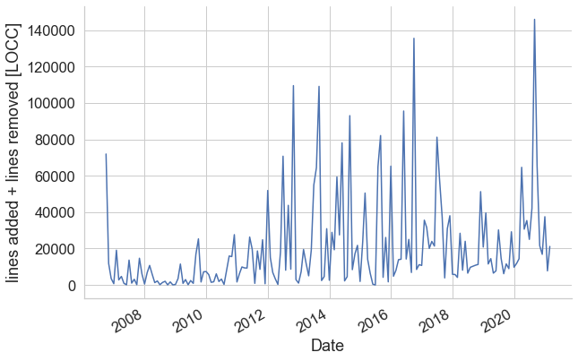

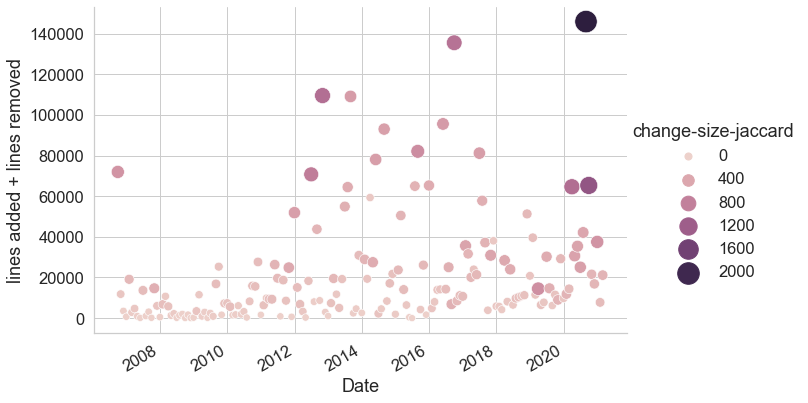

```python
diff_alg = 'jaccard'
df = vis.plot_project_locc_line(diff_alg=diff_alg, log=False)
import seaborn as sns
sns.set(font_scale=1.5)
with sns.axes_style("whitegrid"):
    g = sns.relplot(data=df, x="datetime", y="locc", size="change-size-%s" % diff_alg, hue="change-size-%s" % diff_alg, sizes=(50, 500),
                    height=6, aspect=1.5, kind="scatter")
    g.ax.set_xlabel('Date')
    g.ax.set_ylabel('lines added + lines removed')
    g.fig.autofmt_xdate()
    g.fig.show()
df.head()
```

## Change size over time

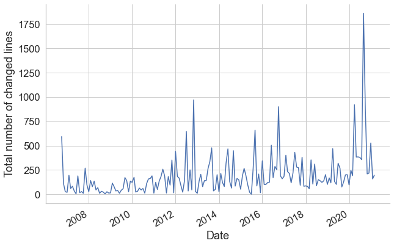

```python
df = vis.plot_proj_change_size(time_range=None)
```

Similarly, we can 'zoom' into a specific year

```
(                              year  month    day      doy    locc  locc-  \
 datetime
 2020-01-31 00:00:00+00:00  1298860    643  12090    12090   11833   4413
 2020-02-29 00:00:00+00:00   618120    612   5203    14689   14400   1150
 2020-03-31 00:00:00+00:00  5013640   7446  54429   203349   64676  26002
 2020-04-30 00:00:00+00:00  2026060   4012  16841   108114   30658  10815
 2020-05-31 00:00:00+00:00  1708920   4230  15812   118178   35406   8003
 2020-06-30 00:00:00+00:00  2050300   6090  15142   169422   25061  10806
 2020-07-31 00:00:00+00:00  1888700   6545  11330   181500   42171  15697
 2020-08-31 00:00:00+00:00  8558740  33896  94688   997169  146001  58933
 2020-09-30 00:00:00+00:00  9776800  43560  49204  1230164   65329  29199
 2020-10-31 00:00:00+00:00  3878400  19200  37672   563752   21593   7301
 2020-11-30 00:00:00+00:00  1018080   5544   8130   161850   16839   7301
 2020-12-31 00:00:00+00:00  3559240  21144  41163   631433   37517  20719

                            locc+  change-size-cos  change-size-jaccard
 datetime
 2020-01-31 00:00:00+00:00   7420       246.477015           282.935286
 2020-02-29 00:00:00+00:00  13250       191.162991           207.720763
 2020-03-31 00:00:00+00:00  38674       921.022302          1003.361754
 2020-04-30 00:00:00+00:00  19843       382.342855           448.946031
 2020-05-31 00:00:00+00:00  27403       383.685376           444.303518
 2020-06-30 00:00:00+00:00  14255       378.934864           476.494033
 2020-07-31 00:00:00+00:00  26474       355.320425           411.584851
 2020-08-31 00:00:00+00:00  87068      1863.629812          2167.363371
 2020-09-30 00:00:00+00:00  36130       881.257984          1307.664053
 2020-10-31 00:00:00+00:00  14292       209.249351           263.905068
 2020-11-30 00:00:00+00:00   9538       216.805707           260.688592
 2020-12-31 00:00:00+00:00  16798       526.763067           596.663927  ,
 <AxesSubplot:xlabel='Date', ylabel='Total number of changed lines'>)
```

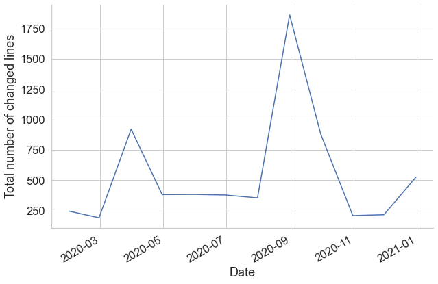

```python
vis.plot_proj_change_size(time_range='year')
```

Or a specific year range

| datetime | year | month | day | doy | locc | locc- | locc+ | change-size-cos | change-size-jaccard | date |
| --- | --- | --- | --- | --- | --- | --- | --- | --- | --- | --- |
| 2006-09-30 00:00:00+00:00 | 1203600 | 5400 | 16201 | 162001 | 71981 | inf | 4.857218 | 2.773055 | 593.000000 | 2006-09-30 |
| 2006-12-31 00:00:00+00:00 | 467398 | 2484 | 2049 | 70384 | 16019 | -4.113576 | 3.481443 | 2.192094 | 167.574302 | 2006-12-31 |
| 2007-03-31 00:00:00+00:00 | 1657782 | 1368 | 19130 | 35245 | 26592 | -3.963363 | 4.240574 | 2.523519 | 404.327766 | 2007-03-31 |
| 2007-06-30 00:00:00+00:00 | 909171 | 2572 | 9265 | 73210 | 14662 | -3.545307 | 4.047353 | 2.352826 | 261.019985 | 2007-06-30 |
| 2007-09-30 00:00:00+00:00 | 274959 | 1064 | 1384 | 29436 | 4286 | -2.905796 | 3.541704 | 1.712100 | 64.261957 | 2007-09-30 |
| 2007-12-31 00:00:00+00:00 | 1649754 | 8525 | 9023 | 242837 | 21208 | -3.834993 | 4.157427 | 2.588715 | 472.184290 | 2007-12-31 |
| 2008-03-31 00:00:00+00:00 | 1590336 | 1428 | 10943 | 30165 | 23309 | -3.923192 | 4.174060 | 2.546993 | 407.275420 | 2008-03-31 |
| 2008-06-30 00:00:00+00:00 | 431720 | 1013 | 2754 | 26934 | 3638 | -2.952308 | 3.438067 | 2.078831 | 133.669552 | 2008-06-30 |
| 2008-09-30 00:00:00+00:00 | 202808 | 765 | 1640 | 21820 | 3445 | -3.023252 | 3.378398 | 1.735567 | 62.239590 | 2008-09-30 |
| 2008-12-31 00:00:00+00:00 | 210840 | 1120 | 1116 | 32032 | 1961 | -2.836324 | 3.105510 | 1.700753 | 57.739895 | 2008-12-31 |
| 2009-03-31 00:00:00+00:00 | 809627 | 669 | 4253 | 12304 | 15833 | -3.463594 | 4.111431 | 2.354037 | 256.337704 | 2009-03-31 |
| 2009-06-30 00:00:00+00:00 | 371665 | 940 | 3534 | 26277 | 5530 | -3.158664 | 3.611617 | 1.944367 | 105.346487 | 2009-06-30 |
| 2009-09-30 00:00:00+00:00 | 1185310 | 4776 | 8200 | 135016 | 43077 | -3.776846 | 4.569315 | 2.563463 | 401.348250 | 2009-09-30 |
| 2009-12-31 00:00:00+00:00 | 1131067 | 6394 | 7793 | 184905 | 16225 | -3.577377 | 4.095030 | 2.447126 | 322.864374 | 2009-12-31 |
| 2010-03-31 00:00:00+00:00 | 1394940 | 924 | 8620 | 15477 | 8851 | -3.562174 | 3.716170 | 2.353254 | 255.778350 | 2010-03-31 |
| 2010-06-30 00:00:00+00:00 | 743700 | 1875 | 5684 | 50985 | 11228 | -3.608740 | 3.855277 | 2.218273 | 192.404625 | 2010-06-30 |
| 2010-09-30 00:00:00+00:00 | 1081380 | 4556 | 8667 | 130535 | 24460 | -3.745855 | 4.276232 | 2.441100 | 306.381943 | 2010-09-30 |
| 2010-12-31 00:00:00+00:00 | 1358760 | 7181 | 13178 | 210748 | 44895 | -3.866405 | 4.574529 | 2.557321 | 388.900807 | 2010-12-31 |
| 2011-03-31 00:00:00+00:00 | 2314661 | 2400 | 18880 | 56030 | 25631 | -4.012542 | 4.185769 | 2.486099 | 418.513947 | 2011-03-31 |
| 2011-06-30 00:00:00+00:00 | 2622344 | 6636 | 21211 | 181666 | 55289 | -3.971508 | 4.662040 | 2.797575 | 721.933282 | 2011-06-30 |
| 2011-09-30 00:00:00+00:00 | 1874252 | 7998 | 18606 | 232992 | 28152 | -4.006466 | 4.255321 | 2.458704 | 353.675444 | 2011-09-30 |
| 2011-12-31 00:00:00+00:00 | 3533327 | 19858 | 18946 | 568407 | 77452 | -4.427194 | 4.705094 | 2.906852 | 886.829686 | 2011-12-31 |
| 2012-03-31 00:00:00+00:00 | 2432508 | 2313 | 15460 | 49174 | 25195 | -3.634779 | 4.319772 | 2.640351 | 485.618884 | 2012-03-31 |
| 2012-06-30 00:00:00+00:00 | 4647720 | 13519 | 25464 | 366055 | 89426 | -4.076713 | 4.889268 | 2.908973 | 1018.917730 | 2012-06-30 |
| 2012-09-30 00:00:00+00:00 | 1364136 | 5387 | 11845 | 155112 | 60557 | -4.330901 | 4.592543 | 2.515712 | 367.391551 | 2012-09-30 |
| 2012-12-31 00:00:00+00:00 | 2432508 | 12203 | 8075 | 342824 | 113551 | -4.744449 | 4.763660 | 3.003460 | 1036.400596 | 2012-12-31 |
| 2013-03-31 00:00:00+00:00 | 2244495 | 2191 | 14149 | 46803 | 38645 | -3.845470 | 4.500223 | 2.620524 | 484.752998 | 2013-03-31 |
| 2013-06-30 00:00:00+00:00 | 2381379 | 6387 | 22690 | 179516 | 79187 | -4.469984 | 4.696147 | 2.734999 | 621.958654 | 2013-06-30 |
| 2013-09-30 00:00:00+00:00 | 2596770 | 9924 | 22358 | 283562 | 176079 | -4.785237 | 5.061045 | 2.928347 | 910.944986 | 2013-09-30 |
| 2013-12-31 00:00:00+00:00 | 885720 | 4811 | 6231 | 139034 | 38090 | -4.322633 | 4.232234 | 2.440801 | 299.967029 | 2013-12-31 |
| 2014-03-31 00:00:00+00:00 | 3051210 | 2109 | 29192 | 47006 | 107611 | -4.751610 | 4.708998 | 2.617819 | 507.154303 | 2014-03-31 |
| 2014-06-30 00:00:00+00:00 | 2835712 | 6644 | 16668 | 173926 | 107849 | -4.734328 | 4.729230 | 2.962770 | 995.992516 | 2014-06-30 |
| 2014-09-30 00:00:00+00:00 | 1941496 | 7778 | 18101 | 224515 | 106036 | -4.581722 | 4.831652 | 2.773945 | 647.069583 | 2014-09-30 |
| 2014-12-31 00:00:00+00:00 | 3157952 | 16374 | 27073 | 476457 | 40795 | -3.775465 | 4.541978 | 2.557184 | 411.499152 | 2014-12-31 |
| 2015-03-31 00:00:00+00:00 | 2827045 | 2915 | 24212 | 69380 | 88289 | -4.779171 | 4.449448 | 2.810483 | 732.065353 | 2015-03-31 |
| 2015-06-30 00:00:00+00:00 | 421135 | 876 | 2433 | 22443 | 6843 | -2.735599 | 3.799272 | 2.065553 | 128.413736 | 2015-06-30 |
| 2015-09-30 00:00:00+00:00 | 2776670 | 10761 | 23437 | 307420 | 151326 | -5.089736 | 4.452921 | 3.008156 | 1068.267183 | 2015-09-30 |
| 2015-12-31 00:00:00+00:00 | 3945370 | 20472 | 48593 | 610353 | 93110 | -4.781892 | 4.513098 | 2.753379 | 610.382006 | 2015-12-31 |
| 2016-03-31 00:00:00+00:00 | 1560384 | 1512 | 12294 | 34764 | 26709 | -3.894150 | 4.275818 | 2.506475 | 362.303425 | 2016-03-31 |
| 2016-06-30 00:00:00+00:00 | 2483712 | 6311 | 18948 | 172918 | 124001 | -4.982719 | 4.445635 | 2.902173 | 858.681104 | 2016-06-30 |
| 2016-09-30 00:00:00+00:00 | 4818240 | 19691 | 28798 | 555569 | 167477 | -5.080800 | 4.672366 | 3.157900 | 1582.902074 | 2016-09-30 |
| 2016-12-31 00:00:00+00:00 | 2586528 | 13967 | 21473 | 407837 | 30397 | -3.881670 | 4.357592 | 2.725707 | 633.154203 | 2016-12-31 |
| 2017-03-31 00:00:00+00:00 | 3531767 | 3401 | 23390 | 72884 | 87349 | -4.664002 | 4.615076 | 2.927610 | 958.606083 | 2017-03-31 |
| 2017-06-30 00:00:00+00:00 | 3951303 | 10479 | 31233 | 287879 | 126556 | -4.646492 | 4.915120 | 2.884661 | 885.541448 | 2017-06-30 |
| 2017-09-30 00:00:00+00:00 | 2505114 | 9422 | 23474 | 270844 | 98856 | -4.678054 | 4.709329 | 2.808753 | 733.846423 | 2017-09-30 |
| 2017-12-31 00:00:00+00:00 | 2478893 | 13300 | 17676 | 384073 | 74865 | -4.453181 | 4.667210 | 2.738249 | 621.049028 | 2017-12-31 |
| 2018-03-31 00:00:00+00:00 | 3148080 | 4232 | 20759 | 99817 | 38302 | -3.798996 | 4.505245 | 2.688749 | 552.952495 | 2018-03-31 |
| 2018-06-30 00:00:00+00:00 | 7228476 | 16545 | 78822 | 467930 | 38604 | -3.938420 | 4.476049 | 2.699296 | 578.908824 | 2018-06-30 |
| 2018-09-30 00:00:00+00:00 | 2916010 | 11618 | 25429 | 333567 | 30880 | -3.808414 | 4.388226 | 2.612687 | 481.319975 | 2018-09-30 |
| 2018-12-31 00:00:00+00:00 | 2306574 | 12661 | 17901 | 367718 | 83401 | -4.587509 | 4.650492 | 2.642958 | 516.487120 | 2018-12-31 |
| 2019-03-31 00:00:00+00:00 | 3498927 | 4299 | 24808 | 100979 | 65618 | -4.615445 | 4.386784 | 2.876485 | 958.316867 | 2019-03-31 |
| 2019-06-30 00:00:00+00:00 | 3375768 | 9106 | 34911 | 259043 | 44498 | -4.114544 | 4.498035 | 2.741431 | 634.675552 | 2019-06-30 |
| 2019-09-30 00:00:00+00:00 | 5895480 | 21129 | 27768 | 577647 | 32404 | -4.097951 | 4.298285 | 2.669942 | 566.641486 | 2019-09-30 |
| 2019-12-31 00:00:00+00:00 | 2919474 | 15342 | 19442 | 441328 | 47965 | -4.422852 | 4.332216 | 2.695413 | 639.220502 | 2019-12-31 |
| 2020-03-31 00:00:00+00:00 | 6930620 | 8701 | 71722 | 230128 | 90909 | -4.499206 | 4.773377 | 3.133112 | 1494.017802 | 2020-03-31 |
| 2020-06-30 00:00:00+00:00 | 5785280 | 14332 | 47795 | 395714 | 91125 | -4.471644 | 4.788882 | 3.058791 | 1369.743583 | 2020-06-30 |
| 2020-09-30 00:00:00+00:00 | 20224240 | 84001 | 155222 | 2408833 | 253501 | -5.016319 | 5.175141 | 3.491391 | 3886.612274 | 2020-09-30 |
| 2020-12-31 00:00:00+00:00 | 8455720 | 45888 | 86965 | 1357035 | 75949 | -4.548033 | 4.608825 | 2.979010 | 1121.257587 | 2020-12-31 |
| 2021-03-31 00:00:00+00:00 | 2740476 | 2204 | 16044 | 42332 | 28918 | -4.062770 | 4.239625 | 2.546194 | 490.161866 | 2021-03-31 |

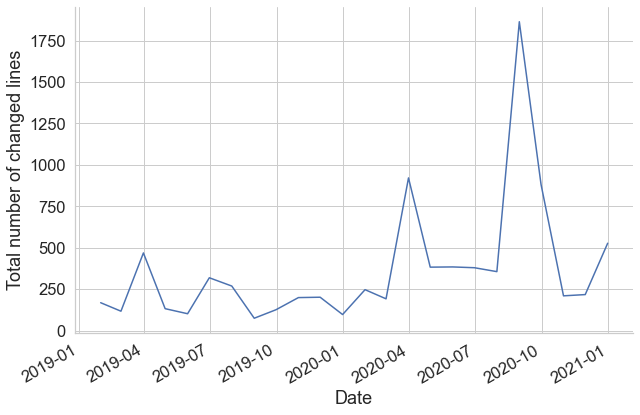

[figure not shown]

```python
vis.select_year_range(2019,2020)
vis.plot_proj_change_size(time_range='year-year')
vis.plot_overall_project_locc(time_range='year-year',log=True)
```

we can zoom into a month

```
(                             year  month   day    doy   locc  locc-  locc+  \
 datetime
 2020-07-01 00:00:00+00:00   26260     91    13   2379    137     41     96
 2020-07-02 00:00:00+00:00   98980    343    98   9016    472    224    248
 2020-07-03 00:00:00+00:00   32320    112    48   2960    210     45    165
 2020-07-04 00:00:00+00:00  177760    616   352  16368   2881    472   2409
 2020-07-05 00:00:00+00:00   34340    119    85   3179    510    179    331
 2020-07-06 00:00:00+00:00   58580    203   174   5452    800    150    650
 2020-07-07 00:00:00+00:00  197960    686   686  18522   1630    349   1281
 2020-07-08 00:00:00+00:00  157560    546   624  14820    502     89    413
 2020-07-09 00:00:00+00:00   64640    224   288   6112   1860    367   1493
 2020-07-10 00:00:00+00:00   54540    189   270   5184   3191   1047   2144
 2020-07-11 00:00:00+00:00   40400    140   220   3860   1278    643    635
 2020-07-12 00:00:00+00:00  303000   1050  1800  29100  12126   5696   6430
 2020-07-13 00:00:00+00:00   44440    154   286   4290   1354     90   1264
 2020-07-14 00:00:00+00:00   48480    168   336   4704   3101    988   2113
 2020-07-15 00:00:00+00:00   20200     70   150   1970     98     33     65
 2020-07-16 00:00:00+00:00  141400    490  1120  13860    638    279    359
 2020-07-17 00:00:00+00:00   36360    126   306   3582    185     96     89
 2020-07-18 00:00:00+00:00   46460    161   414   4600    699    323    376
 2020-07-19 00:00:00+00:00   36360    126   342   3618    398    159    239
 2020-07-20 00:00:00+00:00    4040     14    40    404     49     19     30
 2020-07-21 00:00:00+00:00    6060     21    63    609      0      0      0
 2020-07-22 00:00:00+00:00    8080     28    88    816    114     62     52
 2020-07-23 00:00:00+00:00       0      0     0      0      0      0      0
 2020-07-24 00:00:00+00:00   12120     42   144   1236     78     35     43
 2020-07-25 00:00:00+00:00    8080     28   100    828    315    158    157
 2020-07-26 00:00:00+00:00       0      0     0      0      0      0      0
 2020-07-27 00:00:00+00:00   76760    266  1026   7942    424     97    327
 2020-07-28 00:00:00+00:00    4040     14    56    420    111     52     59
 2020-07-29 00:00:00+00:00   76760    266  1102   8018   8152   3785   4367
 2020-07-30 00:00:00+00:00   34340    119   510   3604    349    116    233
 2020-07-31 00:00:00+00:00   38380    133   589   4047    509    103    406

                            change-size-cos  change-size-jaccard
 datetime
 2020-07-01 00:00:00+00:00         8.490864             9.623399
 2020-07-02 00:00:00+00:00        16.740239            20.719581
 2020-07-03 00:00:00+00:00        11.242958            12.411617
 2020-07-04 00:00:00+00:00        50.933586            54.285589
```

[output cut: 13 more lines]

```
 2020-07-18 00:00:00+00:00         7.088921             9.438366
 2020-07-19 00:00:00+00:00         5.324274             6.352867
 2020-07-20 00:00:00+00:00         1.343586             1.569120
 2020-07-21 00:00:00+00:00         0.000000             0.000000
 2020-07-22 00:00:00+00:00         1.284885             1.520533
 2020-07-23 00:00:00+00:00         0.000000             0.000000
 2020-07-24 00:00:00+00:00         2.710511             3.183080
 2020-07-25 00:00:00+00:00         1.131255             1.848341
 2020-07-26 00:00:00+00:00         0.000000             0.000000
 2020-07-27 00:00:00+00:00         5.765638             6.988852
 2020-07-28 00:00:00+00:00         1.110769             1.203259
 2020-07-29 00:00:00+00:00        16.884850            19.379905
 2020-07-30 00:00:00+00:00         9.364402             9.687628
 2020-07-31 00:00:00+00:00         7.330440             8.899523  ,
 <AxesSubplot:xlabel='Date', ylabel='Total number of changed lines'>)
```

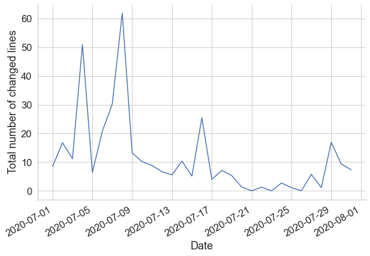

```python
vis.plot_proj_change_size(time_range='month')
```

Or a month range

```
(                              year  month    day      doy    locc  locc-  \
 datetime
 2019-05-31 00:00:00+00:00   391686    970   3561    26841    7751   2536
 2019-06-30 00:00:00+00:00  2245128   6672  26870   194782   30250   8269
 2019-07-31 00:00:00+00:00  5009139  17367  20710   469771   14659   6072
 2019-08-31 00:00:00+00:00   381591   1512   2859    42927    6186   2251
 2019-09-30 00:00:00+00:00   504750   2250   4199    64949   11559   4207
 2019-10-31 00:00:00+00:00  1570782   7780  11407   223801    8964   3426
 2019-11-30 00:00:00+00:00   916626   4994   5386   143402   29231  16402
 2019-12-31 00:00:00+00:00        0      0      0        0       0      0
 2020-01-31 00:00:00+00:00        0      0      0        0       0      0
 2020-02-29 00:00:00+00:00        0      0      0        0       0      0
 2020-03-31 00:00:00+00:00        0      0      0        0       0      0
 2020-04-30 00:00:00+00:00        0      0      0        0       0      0
 2020-05-31 00:00:00+00:00  1708920   4230  15812   118178   35406   8003
 2020-06-30 00:00:00+00:00  2050300   6090  15142   169422   25061  10806
 2020-07-31 00:00:00+00:00  1888700   6545  11330   181500   42171  15697
 2020-08-31 00:00:00+00:00  8558740  33896  94688   997169  146001  58933
 2020-09-30 00:00:00+00:00  9776800  43560  49204  1230164   65329  29199
 2020-10-31 00:00:00+00:00  3878400  19200  37672   563752   21593   7301
 2020-11-30 00:00:00+00:00  1018080   5544   8130   161850   16839   7301

                            locc+  change-size-cos  change-size-jaccard
 datetime
 2019-05-31 00:00:00+00:00   5215       101.238074           114.749965
 2019-06-30 00:00:00+00:00  21981       318.303914           357.856425
 2019-07-31 00:00:00+00:00   8587       268.373157           336.744571
 2019-08-31 00:00:00+00:00   3935        74.063307            89.154193
 2019-09-30 00:00:00+00:00   7352       125.235783           140.742721
 2019-10-31 00:00:00+00:00   5538       198.683385           280.909505
 2019-11-30 00:00:00+00:00  12829       200.906346           239.870324
 2019-12-31 00:00:00+00:00      0         0.000000             0.000000
 2020-01-31 00:00:00+00:00      0         0.000000             0.000000
 2020-02-29 00:00:00+00:00      0         0.000000             0.000000
 2020-03-31 00:00:00+00:00      0         0.000000             0.000000
 2020-04-30 00:00:00+00:00      0         0.000000             0.000000
 2020-05-31 00:00:00+00:00  27403       383.685376           444.303518
 2020-06-30 00:00:00+00:00  14255       378.934864           476.494033
 2020-07-31 00:00:00+00:00  26474       355.320425           411.584851
 2020-08-31 00:00:00+00:00  87068      1863.629812          2167.363371
 2020-09-30 00:00:00+00:00  36130       881.257984          1307.664053
 2020-10-31 00:00:00+00:00  14292       209.249351           263.905068
 2020-11-30 00:00:00+00:00   9538       216.805707           260.688592  ,
 <AxesSubplot:xlabel='Date', ylabel='Total number of changed lines'>)
```

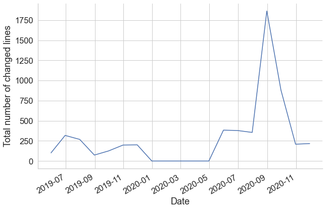

```python
vis.select_month_range(5,11)
vis.plot_proj_change_size(time_range='month-month')
```

## More patterns

Here we look at a combination of the the high-churn and domain champion patterns. Basically we are focusing on the files that have the most changes and restricting the developers by those with the biggest contributions.

| author filepath | sjplimp | Stan Moore | Axel Kohlmeyer | stamoor | Steve Plimpton | tomswinburne | pscrozi | Richard Berger | julient31 | Anne Gunn |
| --- | --- | --- | --- | --- | --- | --- | --- | --- | --- | --- |
| lib/kokkos/tpls...st/gtest-all.cc | 0 | 44343 | 0 | 9854 | 0 | 0 | 0 | 0 | 0 | 0 |
| lib/kokkos/tpls...t/gtest/gtest.h | 0 | 105462 | 0 | 23436 | 0 | 0 | 0 | 0 | 0 | 0 |
| src/KSPACE/pppm.cpp | 39002 | 3 | 1192 | 1 | 381 | 318 | 3668 | 0 | 6 | 120 |
| src/KSPACE/pppm_disp.cpp | 31334 | 2 | 376 | 0 | 80 | 36 | 4 | 0 | 0 | 420 |
| src/MANYBODY/pair_bop.cpp | 20944 | 0 | 736 | 0 | 4 | 853 | 0 | 693 | 0 | 460 |

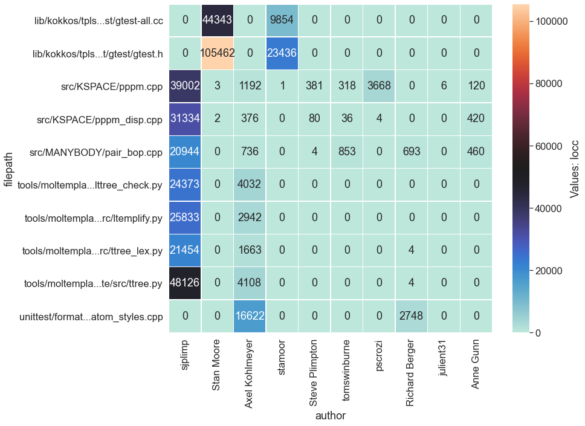

```python
N = 10
vis.set_max_label_length(30)
top_N = vis.plot_top_N_heatmap(N, value_column='locc')
top_N.head()
```

| author filepath | sjplimp | Axel Kohlmeyer | Stan Moore | Steve Plimpton | stamoor | Richard Berger | Anne Gunn | julient31 | tomswinburne | Sebastian Hütter |
| --- | --- | --- | --- | --- | --- | --- | --- | --- | --- | --- |
| lib/kokkos/core...Right_Rank5.cpp | 0.0 | 0.0 | 84.000000 | 0.0 | 0.0 | 0.0 | 0.0 | 0.0 | 0.0 | 0.0 |
| lib/kokkos/core...Right_Rank8.cpp | 0.0 | 0.0 | 94.000000 | 0.0 | 0.0 | 0.0 | 0.0 | 0.0 | 0.0 | 0.0 |
| lib/kokkos/core...tLeft_Rank8.cpp | 0.0 | 0.0 | 94.000000 | 0.0 | 0.0 | 0.0 | 0.0 | 0.0 | 0.0 | 0.0 |
| lib/kokkos/core...tride_Rank4.cpp | 0.0 | 0.0 | 83.902565 | 0.0 | 0.0 | 0.0 | 0.0 | 0.0 | 0.0 | 0.0 |
| lib/kokkos/core...tride_Rank5.cpp | 0.0 | 0.0 | 87.889797 | 0.0 | 0.0 | 0.0 | 0.0 | 0.0 | 0.0 | 0.0 |

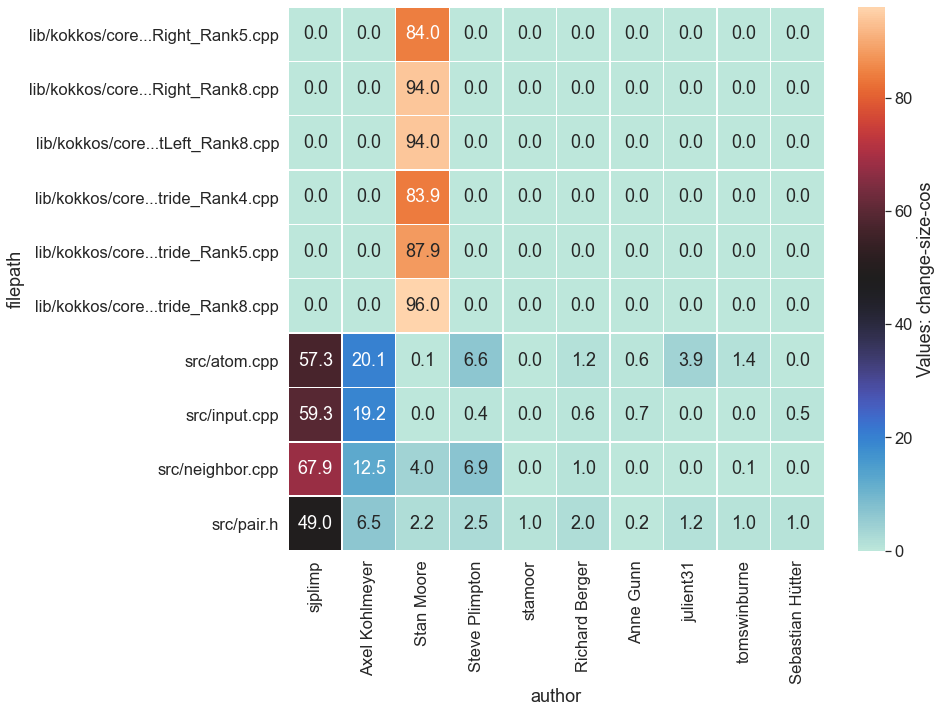

```python
import seaborn as sns
top_N = vis.plot_top_N_heatmap(N, value_column='change-size-cos')
top_N.head()
```

```python
from patterns.patterns import Patterns
df = vis.commit_data
```

```python
vis.reset()
vis.annotate_metrics(diff_alg='cos')
file_dev_locc = vis.make_file_developer_df(value_column='locc')
file_dev_diff = vis.make_file_developer_df(value_column='change-size-cos')
```

```python
diff_df = file_dev_locc.sub(file_dev_diff, axis=0)
print(diff_df.shape)
diff_df.head()
```

```
(7102, 194)
```

| author filepath | Abdo | Abdoreza Ershadinia | Adrian Diaz | Adrian-Diaz | Agilio Padua | Aidan P. Thompson | Aidan Thompson | Amulya | Anders Hafreager | Andrew Jewett | ... | sniblett402 | stamoor | tanmoy.7989 | tomswinburne | toquydong | vishalkenchan | vmohles | wmbrown | wverestek | yafshar |
| --- | --- | --- | --- | --- | --- | --- | --- | --- | --- | --- | --- | --- | --- | --- | --- | --- | --- | --- | --- | --- | --- |
| .github/codecov.yml | 0.0 | 0.0 | 0.0 | 0.0 | 0.0 | 0.0 | 0.0 | 0.0 | 0.0 | 0.0 | ... | 0.0 | 0.0 | 0.0 | 0.0 | 0.0 | 0.0 | 0.0 | 0.0 | 0.0 | 0.0 |
| .github/workflo.../codeql-cpp.yml | 0.0 | 0.0 | 0.0 | 0.0 | 0.0 | 0.0 | 0.0 | 0.0 | 0.0 | 0.0 | ... | 0.0 | 0.0 | 0.0 | 0.0 | 0.0 | 0.0 | 0.0 | 0.0 | 0.0 | 0.0 |
| .github/workflo...cumentation.yml | 0.0 | 0.0 | 0.0 | 0.0 | 0.0 | 0.0 | 0.0 | 0.0 | 0.0 | 0.0 | ... | 0.0 | 0.0 | 0.0 | 0.0 | 0.0 | 0.0 | 0.0 | 0.0 | 0.0 | 0.0 |
| .github/workflo...deql-python.yml | 0.0 | 0.0 | 0.0 | 0.0 | 0.0 | 0.0 | 0.0 | 0.0 | 0.0 | 0.0 | ... | 0.0 | 0.0 | 0.0 | 0.0 | 0.0 | 0.0 | 0.0 | 0.0 | 0.0 | 0.0 |
| .github/workflo...ql-analysis.yml | 0.0 | 0.0 | 0.0 | 0.0 | 0.0 | 0.0 | 0.0 | 0.0 | 0.0 | 0.0 | ... | 0.0 | 0.0 | 0.0 | 0.0 | 0.0 | 0.0 | 0.0 | 0.0 | 0.0 | 0.0 |

5 rows × 194 columns

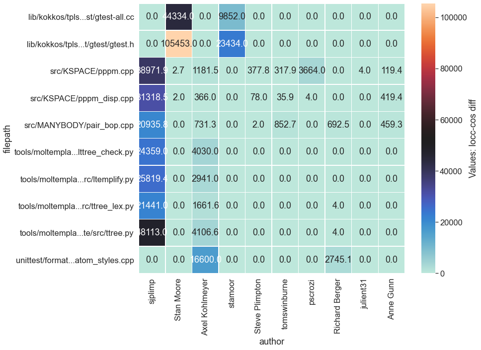

```python
df = vis.commit_data
df['locc-cos diff'] = df['locc']-df['change-size-cos']
d = vis.plot_top_N_heatmap(top_N = 10, value_column='locc-cos diff', my_df=df)
```

## Did anything unusual happen in 2020?

[figure not shown]

```python
vis.how_was_2020('change-size-cos')
```

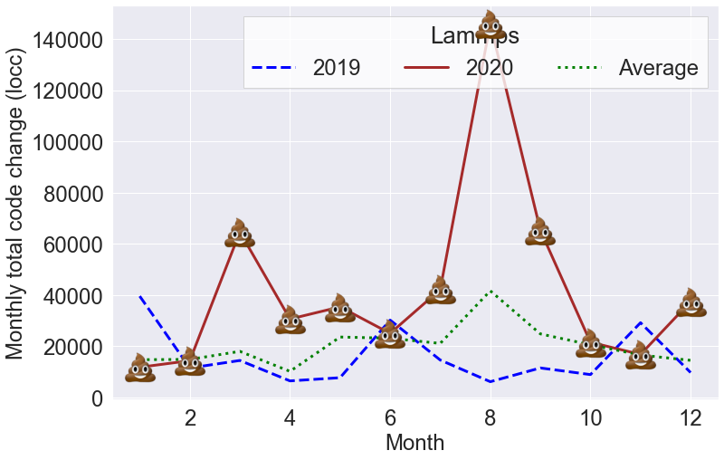

```python
vis.how_was_2020('locc')
```